# Final Project

Shaina Trevino, Jonathan Rochelle, & Andre Klest

5/16/2019

Feedback checklist: * Use a dropdown menu to structure the tutorial blogpost * Fix display of function plot so axis can be read

## Importing data

```r
drug_by_year <- import(here("data", "drug_by_year.csv"),
                       setclass = "tbl_df")

recent_drug <- import(here("data", "2015_drug_dep.csv"),
                      setclass = "tbl_df")
```

# Tutorial

## How to use `purrr::map`!

#### What is `purrr::map`

[figure not shown]

`purrr:map()` is a functional. It takes a vector (or list of vectors) and a function as it’s input, runs the function for each element in the vector and then returns a list.

- The `purrr` package is loaded when you load `tidyverse`

For example, suppose you have a list that contains two other numbered lists with 5 values rounded to two decimal places and you wanted to round them all to the nearest integer.

Our list looks like this:

```r
#creating list from two vectors of decimal values
v <- c(1.85, 2.07, 3.71, 4.21, 5.36)
v1 <- c(1.23, 2.53, 3.44, 4.71, 5.96)
l <- list(v, v1)
l
```

```
## [[1]]
## [1] 1.85 2.07 3.71 4.21 5.36
##
## [[2]]
## [1] 1.23 2.53 3.44 4.71 5.96
```

If we only had 1 vector to round, we could use the `round()` function

```r
round(v)
```

```
## [1] 2 2 4 4 5
```

However, this does not work when supplied our list

```r
round(l)
```

```
## Error in round(l): non-numeric argument to mathematical function
```

Instead, we need a function that will apply `round()` to every element in our list. That’s where we can use `map()`

```r
#takes vector and rounds up
map(l, round)
```

```
## [[1]]
## [1] 2 2 4 4 5
##
## [[2]]
## [1] 1 3 3 5 6
```

Notice how the output from `map()` is a list, and the `round()` function has been applied to each element in the list.

You could also use `map()` with a single vector, however, in this case, the output is the same as when solely using the `round()` function. Additionally, you can adjust which decimal that you would like to round to by specifying the digits.

```r
map(v, round, digits = 1)
```

```
## [[1]]
## [1] 1.8
##
## [[2]]
## [1] 2.1
##
## [[3]]
## [1] 3.7
##
## [[4]]
## [1] 4.2
##
## [[5]]
## [1] 5.4
```

However, as mentioned above, this output is a list. When you have an atomic vector as an input or a list of numbered lists of length 1, you can coerce your output to an atomic vector. This coercion allows the function to utilize values that work within the operation called on.

#### `map()` variants

You can override the return of list and instead return an atomic vector by using variants of `map()`:

```
* `map_dbl` returns vector of type double

* `map_chr` returns a vector of type character

* `map_lgl` returns a vector of type logical (e.g., `TRUE` or `FALSE`)

* `map_int` returns a vector of type integer
```

For example, if we use `map_dbl` or `map_chr` for our previous example, we will have the same results, but the output will be different types.

```r
#return vector of type double
map_dbl(v, round)
```

```
## [1] 2 2 4 4 5
```

```r
#return vector as character
map_chr(v, round)
```

```
## [1] "2.000000" "2.000000" "4.000000" "4.000000" "5.000000"
```

Notice how the numbers are actually the same, but `map_dbl` returns a numeric vector, whereas `map_chr` returns a character vector.

What if we wanted to know if each element in our vector is of type double, we would want to return a logical vector that tells us if the value is double (e.g., `TRUE`) or not (e.g., `FALSE`)

```r
#return vector of type logical
map_lgl(v, is.double)
```

```
## [1] TRUE TRUE TRUE TRUE TRUE
```

This logical vector tells us that each element is of type double.

`map_int` returns an integer vector (i.e., whole numbers), therefore, we can use it to ask questions like: what is the length of each element in my vector?

```r
#return vector of type integer
map_int(v, length)
```

```
## [1] 1 1 1 1 1
```

In this example, there is only 1 value per element in the vector, so all the lengths are 1.

If we use the same code on our list object, it should tell us how many numbers are in each element of the list.

```r
map_int(l, length)
```

```
## [1] 5 5
```

There are 2 elements in our list and each has 5 values.

### Information about the data

Data used in this tutorial came from the Center for Disease Control and Prevention’s (CDC) National Health and Nutrition Examination Survey (NHANES). The study began in 1999 and the most recent data collected and publicly available are from 2015-2016.

These data and codebooks are available online [here](https://www.cdc.gov/nchs/nhanes/about_nhanes.htm).

NHANES surveys around 5,000 participants accross the U.S. each year. Surveys include demographic, socioeconomic, dietary, and health related questions, as well as medical records, physiological assessments, and laboratory test.

For this tutorial we will use two data frames:

1. `drug_by_year` includes data from 2005 to 2015 and reports on the people who responded yes to using illicit substances in the last year.
2. `recent_drug` includes has data from 2015-2016 and shows the age of first drug use, a summed depression score, whether or not participants have been to rehab, have access to mental health services, and have health insurance.

### Using `map()` in data frames

Since `map()` can take a vector for an input, and data frames are lists containing vectors, you can use `map` to iterate through data frames.

For example, say we want to use the NHANES data to calculate the mean for age of first use for each drug and depression scores. Since there are quite a bit of missing values in this data set, so we will need to add arguments to the mean function to ignore the missing data.

The data frame looks like this

```
## # A tibble: 4,843 x 6
##    age_cocaine age_heroin age_meth age_marijuana age_stim sum_depression
##          <int>      <int>    <int>         <int>    <dbl>          <int>
##  1          NA         NA       NA            NA       NA              1
##  2          NA         NA       NA            NA       NA              2
##  3          NA         NA       NA            NA       NA              1
##  4          NA         NA       NA            25       NA             13
##  5          NA         NA       NA            15       NA              8
##  6          NA         NA       NA            18       NA              0
##  7          NA         NA       NA            NA       NA              1
##  8          20         NA       NA            18       NA              1
##  9          NA         NA       NA            NA       NA             NA
## 10          21         NA       21            21       21              0
## # ... with 4,833 more rows
```

To add arguments to a function within `map()`, we need to create an inline anonymous function where your function is first specified with `function(x)` where `x` is a place holder for what the function is going to run on. Then you write a function that you want to run on each element (`x`).

Therefore, to calculate the means, our `map()` function would look like this

```r
means <- map_dbl(d, function(x) mean(x, na.rm = TRUE))
means
```

```
##    age_cocaine     age_heroin       age_meth  age_marijuana       age_stim
##      21.342308      23.870968      21.623116      17.289796      20.792105
## sum_depression
##       3.314233
```

There is also a shortcut you can use within `map()` functions where you don’t have to specify `function(x)`.

```r
means <- map_dbl(d, ~ mean(.x, na.rm = TRUE))
means
```

```
##    age_cocaine     age_heroin       age_meth  age_marijuana       age_stim
##      21.342308      23.870968      21.623116      17.289796      20.792105
## sum_depression
##       3.314233
```

These two examples are exactly the same, the latter just has less code. `function(x)` is implied with the `~` and then you just have to use `.x` instead of `x` for what you are iterating over.

#### `map_df()`

There is another `map()` variant that is useful when working with data frames, `map_df()`.

You can use `map_df()` to return a data frame as the output instead of an atomic vector.

For example, say we want to return a data frame of the means and standard deviations of each column within our data frame.

You would expect the below example to work, but it doesn’t because only the last line in the function is being evaluated and printed, so we only get standard deviations as the output. Also note you need to use curly braces for longer functions as seen here.

```r
map_df(d, function(x) {
  mean(x, na.rm = TRUE)
  sd(x, na.rm = TRUE)
})
```

```
## # A tibble: 1 x 6
##   age_cocaine age_heroin age_meth age_marijuana age_stim sum_depression
##         <dbl>      <dbl>    <dbl>         <dbl>    <dbl>          <dbl>
## 1        5.51       8.11     7.19          4.56     5.44           4.41
```

Instead, you need to instead use `summarize()` to work within the data frame and `summarize()` each vector

```r
#creating a vector for the column names to add to data frame
column_names <- colnames(d)

map_df(d, function(x) {
  summarize(d, mean = mean(x, na.rm = TRUE),
            sd = sd(x, na.rm = TRUE))
}, .id = "column_names")
```

```
## # A tibble: 6 x 3
##   column_names    mean    sd
##   <chr>          <dbl> <dbl>
## 1 age_cocaine    21.3   5.51
## 2 age_heroin     23.9   8.11
## 3 age_meth       21.6   7.19
## 4 age_marijuana  17.3   4.56
## 5 age_stim       20.8   5.44
## 6 sum_depression  3.31  4.41
```

Or you could do the above in two separate steps, using `map()` to loop the functions through vectors and then put the vectors into a data frame

```r
#first create vectors by looping functions through data frames
mean <- map(d, ~mean(.x, na.rm = TRUE))
sd <- map(d, ~sd(.x, na.rm = TRUE))
#then combine vectors
cv <- c(mean, sd, recursive = TRUE)
#manually change attributes
attr(cv, "dim") <- c(6, 2) #6 variables in two columns (mean and sd)
colnames(cv) <- c("mean", "sd")
#transform to data frame
cv <- data.frame(cv, row.names = column_names)
cv
```

```
##                     mean       sd
## age_cocaine    21.342308 5.514226
## age_heroin     23.870968 8.106836
## age_meth       21.623116 7.193829
## age_marijuana  17.289796 4.558000
## age_stim       20.792105 5.436277
## sum_depression  3.314233 4.411444
```

#### Parallel Iteration (e.g., `map2_*`, `pmap_*`)

The `map` variants discussed above all take a single input to iterate (i.e., call the function on), but sometimes you need to iterate through more than just one input.

This can be accomplished with `map2_` or `pmap_`

- `map2_` iterates over two inputs (e.g., two vectors)
- `pmap_` iterates over any number of inputs

For example, say you wanted to calculate a weighted mean from a vector of data values and a vector of weights.

```r
#create vectors for simulated data from mean distribution of our data and weights
obs <- map(1:1715, ~rnorm(n = 20, mean = 17.289, sd = 4.558))
wts <- map(1:1715, ~rpois(20, 5))
```

```r
map_dbl(obs, ~weighted.mean(.x, w = wts))
```

```
## Error in weighted.mean.default(.x, w = wts): 'x' and 'w' must have the same length
```

Instead, we need a parallel iteration with `map2()` to run the function on each vector of observation with each corresponding vector of weights.

Also, notice that when using `map2()` you will have an additional argument `.y`, along with `.x`, that corresponds to the second vector you are iterating through.

```r
#note that we used head() to prevent the entirety of the extensive list to be displayed
head(map2_dbl(obs, wts, ~weighted.mean(.x, .y)))
```

```
## [1] 16.17096 17.28661 17.72167 16.11413 18.47819 16.58427
```

The results is a weighted mean score for each participant.

#### `pmap()` briefly

`pmap()` can be supplied any number of inputs that you provide in a single list. This list can contain any number of inputs or arguments.

`pmap()` is very useful when working with data frames in which there are many vectors of the same length that can be provided as inputs (i.e., columns)

You can name the inputs in the list which is helpful when iterating through complex functions

We will show you how to use `pmap` to iterate and build custom plots in a later blog post

#### Other `purrr` functions (e.g., `walk_*`, `reduce`, `modify_*`)

The `map()` variants discussed above all return an output (either an atomic vector or list). However, sometimes you don’t need to return an atomic vector or list, but iteration would still be helpful.

Very useful variant of `map()` is `walk()`, specifically `walk2()` which can be used to save objects to a disk. Note: when saving something to a disk you have to provide 2 inputs: the object and the file path - this requires parallel iteration.

The following code splits our longitudinal dataset by year and saves a separate .csv file for each year with the title (“year-2005”, etc.) in the data folder of the working directory

```r
by_year <- split(drug_by_year, drug_by_year$year)
paths <- here("data", paste0("year-", names(by_year), ".csv"))
walk2(by_year, paths, write.csv)


list.files("data")
```

[output not shown]

Other useful functions are:

- `reduce()` takes a vector of any length as it’s input and returns a vector of length 1. For example `reduce(1:4, f)` returns `f(f(f(1, 2), 3), 4)`.
- `modify()` returns the same type of input it is provided. For example, `modify(df, f)` will run the function on each column of the data frame and return a data frame as the output.

#### Using `mutate` within `nest()` is powerful in list columns

The data frames we have worked with so far have all contained columns of atomic vectors, however you can also have columns of lists within data frames (i.e., list column).

You can use `group_by()` and `nest()` to split your data into list columns then apply `mutate` to:

1. fit models by the grouping factor and extract coefficients
2. compare model fits
3. extract means from models fit with two groups
4. fit multiple different models for each grouping factor and view coefficients

First, we need to transform our data a bit so that we can properly fit our models.

```r
dat <- recent_drug %>%
  select(-1:-2, -age_stim) %>%
  gather(drug, age_use, -age, -sum_depression:-sex) %>%
  separate(drug, c("dis", "drug"), sep = "_") %>%
  select(-dis) %>%
  filter(!is.na(age_use)) %>%
  mutate(mental_health = ifelse(mental_health == "Yes", "Yes", "No"),
         sex = fct_relevel(sex, ref = "Male"),
         mental_health = fct_relevel(mental_health, ref = "No"))
```

Then, we will use `group_by()` and `nest()` to split our data by each type of drug, fit a model that predicts age of first use from participant sex for each drug category, and view the coefficients.

```r
#fit one model per drug and view coefficients
by_drug_coefs <- dat %>%
  group_by(drug) %>%
  nest() %>%
  mutate(model = map(data, ~lm(age_use ~ sex, data = .x)),
         coef = map(model, ~tidy(.x))) %>%
  unnest(coef)
by_drug_coefs
```

```
## # A tibble: 8 x 6
##   drug      term        estimate std.error statistic   p.value
##   <chr>     <chr>          <dbl>     <dbl>     <dbl>     <dbl>
## 1 cocaine   (Intercept)   21.7       0.338    64.2   8.94e-249
## 2 cocaine   sexFemale     -0.700     0.483    -1.45  1.48e-  1
## 3 heroin    (Intercept)   24.7       1.54     16.0   2.25e- 23
## 4 heroin    sexFemale     -1.47      2.08     -0.709 4.81e-  1
## 5 meth      (Intercept)   21.4       0.703    30.4   2.59e- 76
## 6 meth      sexFemale      0.513     1.02      0.501 6.17e-  1
## 7 marijuana (Intercept)   17.1       0.156   110.    0.
## 8 marijuana sexFemale      0.329     0.220     1.50  1.35e-  1
```

Next, we can compare all model fits (note the model fits will not be good since our models were not significant).

```r
#Look at model fit stats per drug model
by_drug_fit <- dat %>%
  group_by(drug) %>%
  nest() %>%
  mutate(model = map(data, ~lm(age_use ~ sex, data = .x)),
         fit = map(model, ~glance(.x))) %>%
  unnest(fit)
by_drug_fit
```

```
## # A tibble: 4 x 14
##   drug  data  model r.squared adj.r.squared sigma statistic p.value    df
##   <chr> <lis> <lis>     <dbl>         <dbl> <dbl>     <dbl>   <dbl> <int>
## 1 coca~ <tib~ <S3:~   0.00403      0.00211   5.51     2.10    0.148     2
## 2 hero~ <tib~ <S3:~   0.00831     -0.00822   8.14     0.503   0.481     2
## 3 meth  <tib~ <S3:~   0.00127     -0.00380   7.21     0.251   0.617     2
## 4 mari~ <tib~ <S3:~   0.00131      0.000723  4.56     2.24    0.135     2
## # ... with 5 more variables: logLik <dbl>, AIC <dbl>, BIC <dbl>,
## #   deviance <dbl>, df.residual <int>
```

Finally, we can also extract the mean age of first use for males and females for each drug

```r
#mean age of use for males and females in first model
by_drug_sex <- dat %>%
  group_by(drug) %>%
  nest() %>%
  mutate(model = map(data, ~lm(age_use ~ sex, data = .x)),
         coefs = map(model, coef),
         males = map_dbl(coefs, 1),
         females = males + map_dbl(coefs, 2)) %>%
  select(drug, males, females)
by_drug_sex
```

```
## # A tibble: 4 x 3
##   drug      males females
##   <chr>     <dbl>   <dbl>
## 1 cocaine    21.7    21.0
## 2 heroin     24.7    23.2
## 3 meth       21.4    21.9
## 4 marijuana  17.1    17.5
```

Another powerful use of list columns is being able to fit multiple models by each drug. Then, you could run through the same steps as above to compare model fits, etc.

```r
#fit multiple models by year
by_drug_models <- dat %>%
  group_by(drug) %>%
  nest() %>%
  mutate(m1 = map(data, ~lm(age_use ~ sex, data = .x)),
         m2 = map(data, ~lm(age_use ~ sex + mental_health, data = .x)),
         m3 = map(data, ~lm(age_use ~ sex * mental_health, data = .x)))
```

## Functions

As we saw in the previous post, using pre-formed functions in R (e.g., `map()`) can be incredibly useful for iterating through lists and data frames in an efficient and time-saving manner. An alternative or supplementary choice to using packages like `purrr` is the option of writing your own custom R functions independently of any function package. Previously, we learned how to add an inline anonymous function `function(x)` to `map()` in order to add additional arguments. Now we will cover how to formulate a custom function.

#### What is a function?

[figure not shown]

In R, a function can be defined as any formula that carries out some type of operation. For example:

```r
100/5*7
```

```
## [1] 140
```

In this case, each mathematical operation (i.e., / and *) can be defined as a function.

For all functions, there are three essential components:

1. body(): a collection of statements that defines what a function does
2. formals(): is the argument supplied to the function
3. environments(): collection of objects in a function

```r
# example function
square <- function(x) {
  x^2
}
# use of the function
sum(2)
```

```
## [1] 2
```

There are several different ways that functions can be saved:

1. It can be stored as an object, which could be useful if you are planning on using it for future tasks.

```r
triple <- function(x) {
  x*3
}
```

2. It can be stored as a list, which could allow you to run more than one function in a loop

```r
fun_list <- list(n = ~length(x),
                 n_miss = ~sum(is.na(x)),
                 mean = ~mean(x, na.rm = TRUE),
                 sd = ~sd(x, na.rm = TRUE),
                 min = ~min(x),
                 max = ~max(x))
```

3. It can be an anonymous function, which could be used when it is only going to be used once.

```r
function(x) {
  x*3
}
```

```
## function(x) {
##   x*3
## }
```

### Function2: Summarize Mean, SD, Min, and Max using by a Group_By Variable

1. First we name the data set, the outcome variable, and the grouping variable. We will use these to call up this info when applying the completed function.
2. Next, we use “enquo”, part of the ‘dplyr’ package which should be loaded if you have not already done so, to select the variables we are planning to use in defining the function. Enquo helps R search for these variables within our data frame instead of searching the global environment for them. When using enquo the “!!” symbol will be necessary anytime we want to refer back to these variables that we are defining here in the first steps of creating our function. EX. instead of writing mean(our_var_name) as usual we will need to write mean(!!our_var_name).
3. The %>% symbol is a pipe operator and is used to feed each piece of our function through the proceeding statement, so that at each step the result of the previous argument is fed through the following argument. Ex. dataset %>% step1 %>% step2.

4)“group_by” tells R to divide the outcome into a separate row for each category of the grouping variable.

5. “summarize” is the step where we invoke the operations and calculations on our outcome variable. The results of the summarize step should be separated thanks to the group_by statement in step 4,

```r
library(dplyr)

fun2_mean1group <- function(data, cat_var, num_var){
  cat_var <- enquo(cat_var)
  num_var <- enquo(num_var)
  data %>% #if (cat_var2 < 17)
    group_by(!!cat_var) %>%
    summarize(mean = mean(!!num_var, na.rm = TRUE),
              sd = sd(!!num_var, na.rm = TRUE),
              min = min(!!num_var, na.rm = TRUE),
              max = max(!!num_var, na.rm = TRUE))
}

fun2_mean1group(recent_drug, mental_health, age_marijuana)
#fun2_mean1group(iris, Species, Sepal.Width)
```

[output not shown]

### Function 3: Two grouping variables

5. If you wish to add a second “group_by” variable start by including a variable name in the Function itself, and include an additional enquo command
6. Now in the “group_by” command include a second variable using the “!!” as before. ex: group_by(!!group_var1, !!group_var2)
7. after the “summarize” command include an additional %>% and add the “spread” command naming the variable as before (!!group_var1), and indicating the outcome you wish to report.

```r
fun3_mean2groups <- function(x, cat_var1, cat_var2, outcome_var){
  cat_var1 <- enquo(cat_var1)
  cat_var2 <- enquo(cat_var2)
  num_var <- enquo(outcome_var)

  x %>%
    group_by(!!cat_var1, !!cat_var2) %>%
    summarize(mean = mean(!!num_var, na.rm = TRUE),
              sd = sd(!!num_var, na.rm = TRUE),
              min = min(!!num_var, na.rm = TRUE),
              max = max(!!num_var, na.rm = TRUE))%>%
    spread(!!cat_var1, mean)
}

fun3_mean2groups(recent_drug, mental_health, income, age_marijuana)
```

```
## # A tibble: 48 x 8
##    income                sd   min   max `Don't know`    No   Yes `<NA>`
##    <chr>              <dbl> <dbl> <dbl>        <dbl> <dbl> <dbl>  <dbl>
##  1 $0 - $4,999         4.57    10    21           NA  NA    15.2   NA
##  2 $0 - $4,999         4.63     8    23           NA  NA    NA     16.2
##  3 $0 - $4,999         4.83     7    30           NA  17.5  NA     NA
##  4 $100,000 and over   5.26    13    39           NA  NA    NA     18.5
##  5 $100,000 and over   5.61     6    50           NA  17.7  NA     NA
##  6 $100,000 and over   8.82    13    45           NA  NA    19.8   NA
##  7 $15,000 to $19,999  2.12    13    19           NA  NA    15.5   NA
##  8 $15,000 to $19,999  3.39     9    24           NA  NA    NA     16.0
##  9 $15,000 to $19,999  3.91    10    35           NA  17.0  NA     NA
## 10 $20,000 to $24,999  2.57    12    22           NA  NA    16     NA
## # ... with 38 more rows
```

```r
#fun3_mean2groups(iris, Species, Petal.Width, Sepal.Width)
```

### Function 4: Creating a Function Using GGPlot

To plot our outcome variable, in this case age of first marijuana use, we can create a function which will plot the age of first grouped by variable of interest. To test our function we will use “income” as category to group age of first marijuana use against on the x-axis.

1. Once again we begin by naming the variables our function will use to pull data from. In this case we will include a data variable to name the dataset, “x” for our x-axis variable, and “y” for our y-axis variable.
2. Next, in the open bracket, we will include our plotting function in this case ggplot, and we will name the dataset and x/y variables so they match the variable names we will use in the final function.
3. Now we add the method we will use to plot, choosing one of the ggplot options. In this case, we selected ‘geom_point’ which will provide a number of dots along the y-axis for each category. A color can also be selected. Ex. geom_point(color = “magenta”).

```r
fun4_plot <- function(data, x, y) {
    ggplot(data, aes_string(x, y)) +
      geom_point(color = "blue")
}

fun4_plot(recent_drug, "income", "age_marijuana")
```

[output not shown]

### Function 5: Plotting Mean, SD, Min, & Max

```r
#not working can delete
  fun5_plotsummary <- function(filename) {
  dat <- read.csv(file = filename, header = FALSE)
  mean_age <- apply(dat, 2, mean, na.rm = TRUE)
  plot(mean_age)
  sd_age <- apply(dat, 2, sd, na.rm = TRUE)
  max_age <- apply(dat, 2, max, na.rm = TRUE)
  plot(max_age)
  min_age <- apply(dat, 2, min, na.rm = TRUE)
  plot(min_age)
}

fun4_plot(recent_drug)
```

[output not shown]

## Putting it All Together

[figure not shown]

### Review

When you move to working with your own data in the real-world, often you need to address complex questions that may not perfectly align with either a custom function that you wrote or a variant of `map()`. In these cases, it is often useful to synthesize or combine the functions together in order to create a viable solution to the question you are trying to address. In this last post, we are going to do exactly that by using `pmap()` and a custom function to create a trove of custom plots! Finally, we will go over how to save these plots into a file. But before we do, let’s review what we have learned so far.

#### Purr

At the beginning of this tutorial, we started out by learning how to use the `purr` package to apply useful arguments (e.g., `round`) to multiple items in a list through the `map()` function. We then learned how `map()` and its variant `map_df()` can be utilized to iterate through data frames. Additionally, we found out in the case of parallel iteration, the functions `map2_*` and `pmap_*` can be used to iterate through more than a single input.

#### Functions

Functions allow us to create custom solutions to any problem we are addressing independent of a pre-made package. Remember, anything that carries out an operation is a function, however, for our purposes we go beyond this definition by using the *body* and *formals* descriptions to better define how to formulate a function.

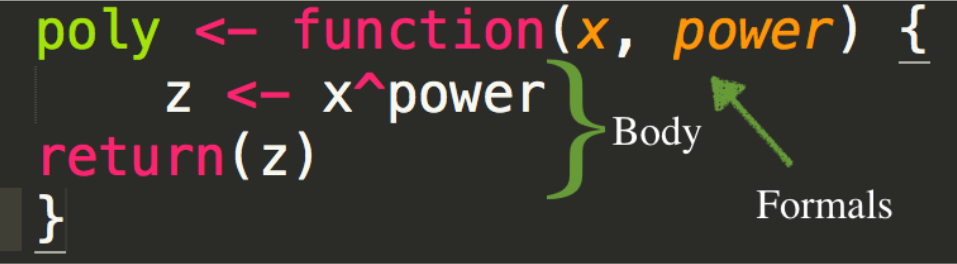

All rights to Daniel Anderson

### Application

In this final section, we want to use `pmap()` to build custom plots that are able to visualize data across multiple inputs from a list. The question that we are looking to answer is: * How does average depression levels differ for males vs females across ethnicity. Answering this question in a singular plot would be pretty simple. But what if we want to answer this question but also see how these differences look across income levels and mental health services. That is Where the use of `pmap()` enters the picture! Before we apply `pmap()` we first want to nest our data into a list where the variables of interest (i.e., sex, ethnicity, depression levels) are nested within both mental health and income levels.

```r
dat_1 <- dat %>%
  #get rid of the variables we are not going to use
  select(-age, -rehab, -insurance, -age_use, -drug) %>%
  #nest the remaining variables of interest within income and mental health
  nest(-income, -mental_health)
```

Now we use `pmap()` and our anonymous function to create a set of custom plots. In order to apply the function across the variables of mental health and income levels, we will use the `glue` package.

```r
plots <- dat_1 %>%
  # The first step is to use mutate to apply the pmap function on the variables we will be iterating through and then write an anonymous function using the specifications from pmap
  mutate(plots = pmap(list(data = dat_1$data, income = dat_1$income, mental_health = dat_1$mental_health), function(data, income, mental_health) {
    # Now we will embed the ggplot code within the body of our function
    ggplot(dat) +
    geom_bar(aes(ethnicity, sum_depression, fill = sex), stat = "summary", fun.y = "mean", position = "dodge", alpha = 0.7) +
      # Add aesthetics to the plot
      theme_minimal() +
      scale_fill_viridis_d() +
      coord_flip() +
      # in the labels section use the glue argument to iterate across income for the titles and mental health sercies for caption.
      labs(title = glue("Depression Scores for Individuals Making {income}"), subtitle = "Comparison across sex and ethnicity", caption = glue("Access to mental health services: {mental_health}"), y = "Mean Depression Score", x = "Ethnicity")
  }))

#showing access to mental health services as a 1 or 2, instead of yes vs no.
```

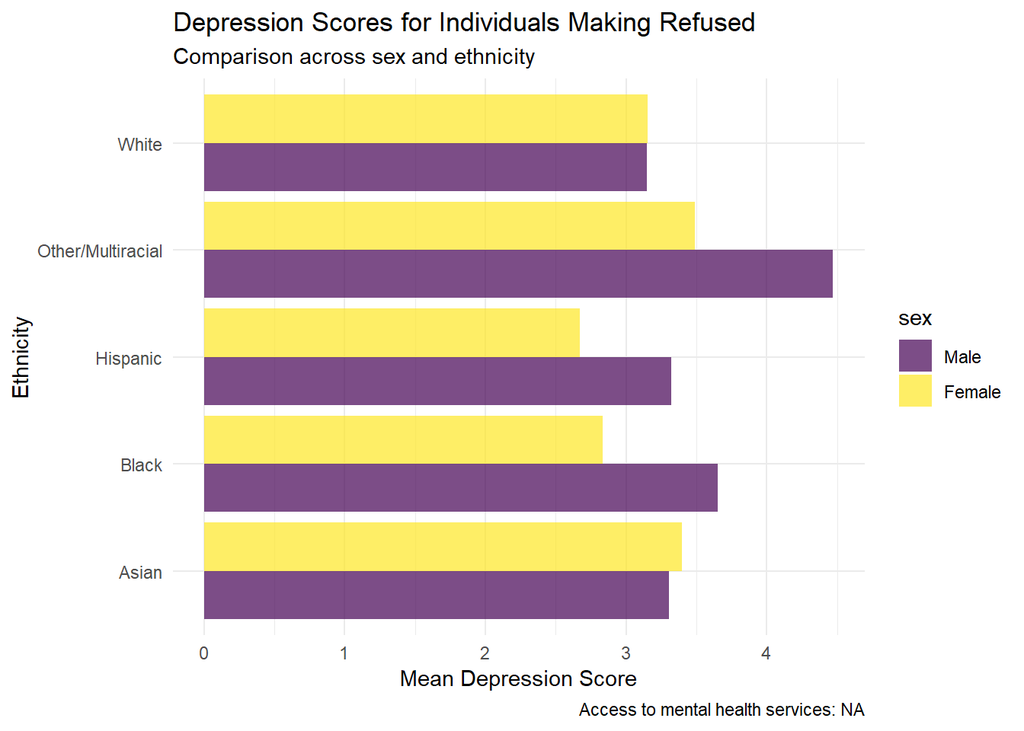

```r
plots$plots[[43]]
```

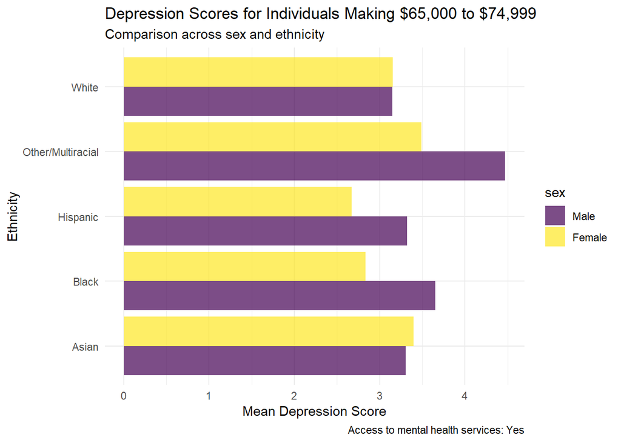

```r
plots$plots[[20]]
```

Finally, we want to save our work! To do this we combine the different skills we have learned including `glue` and `walk2`

```r
# create an object files that uses meaningful names for the plots
files <- str_replace_all(tolower(plots$income), " ", "-")
# create the plot folder
fs::dir_create(here::here("plots"))
# use the glue function to apply the object files to each plot
paths <- here::here("plots", glue("{files}.png"))
# walk2 specifies the path and sizes of plots
walk2(paths, plots$plots, ggsave,
      width = 9.5, height = 6.5, dpi = 500)
```

[output not shown]

[output cut: 32 more lines]

[output not shown]

```r
#only saved 15 plots instead of th 44. It is because I am saving it by income only, how do I had the mental health services also?
```